# Data 621 - Homework 3

Group 2: William Aiken, Donald Butler, Michael Ippolito, Bharani Nittala, and Leticia Salazar

11-06-2022

$~$

## Overview:

In this homework assignment, you will explore, analyze and model a data set containing information on crime for various neighborhoods of a major city. Each record has a response variable indicating whether or not the crime rate is above the median crime rate (1) or not (0).

$~$

## Objective:

Build a binary logistic regression model on the training data set to predict whether the neighborhood will be at risk for high crime levels. You will provide classifications and probabilities for the evaluation data set using your binary logistic regression model. You can only use the variables given to you (or variables that you derive from the variables provided).

$~$

## Description:

Below is a short description of the variables of interest in the data set:

$~$

### Load Libraries:

```r
library(tidyverse)
library(caret)
library(pROC)
library(corrplot)
library(GGally)
library(psych)
library(car)
library(kableExtra)
library(gridExtra)
library(performance)
```

$~$

### Load Data set:

We have included the original data sets in our GitHub account and read from this location.

```r
dftrain <- read.csv("https://raw.githubusercontent.com/letisalba/Data_621/master/Homework_3/csv/crime-training-data_modified.csv")
glimpse(dftrain)
```

```
## Rows: 466
## Columns: 13
## $ zn      <dbl> 0, 0, 0, 30, 0, 0, 0, 0, 0, 80, 22, 0, 0, 22, 0, 0, 100, 20, 0…
## $ indus   <dbl> 19.58, 19.58, 18.10, 4.93, 2.46, 8.56, 18.10, 18.10, 5.19, 3.6…
## $ chas    <int> 0, 1, 0, 0, 0, 0, 0, 0, 0, 0, 0, 0, 0, 0, 0, 0, 0, 0, 0, 0, 0,…
## $ nox     <dbl> 0.605, 0.871, 0.740, 0.428, 0.488, 0.520, 0.693, 0.693, 0.515,…
## $ rm      <dbl> 7.929, 5.403, 6.485, 6.393, 7.155, 6.781, 5.453, 4.519, 6.316,…
## $ age     <dbl> 96.2, 100.0, 100.0, 7.8, 92.2, 71.3, 100.0, 100.0, 38.1, 19.1,…
## $ dis     <dbl> 2.0459, 1.3216, 1.9784, 7.0355, 2.7006, 2.8561, 1.4896, 1.6582…
## $ rad     <int> 5, 5, 24, 6, 3, 5, 24, 24, 5, 1, 7, 5, 24, 7, 3, 3, 5, 5, 24, …
## $ tax     <int> 403, 403, 666, 300, 193, 384, 666, 666, 224, 315, 330, 398, 66…
## $ ptratio <dbl> 14.7, 14.7, 20.2, 16.6, 17.8, 20.9, 20.2, 20.2, 20.2, 16.4, 19…
## $ lstat   <dbl> 3.70, 26.82, 18.85, 5.19, 4.82, 7.67, 30.59, 36.98, 5.68, 9.25…
## $ medv    <dbl> 50.0, 13.4, 15.4, 23.7, 37.9, 26.5, 5.0, 7.0, 22.2, 20.9, 24.8…
## $ target  <int> 1, 1, 1, 0, 0, 0, 1, 1, 0, 0, 0, 0, 1, 1, 0, 0, 0, 1, 1, 1, 0,…
```

```r
dfeval <- read.csv("https://raw.githubusercontent.com/letisalba/Data_621/master/Homework_3/csv/crime-evaluation-data_modified.csv")
```

$~$

## Data Exploration:

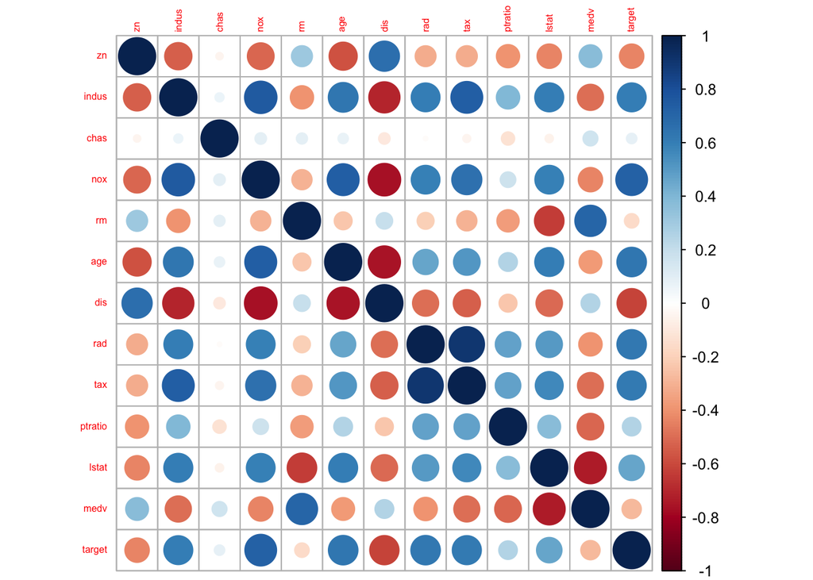

```r
corrplot(cor(dftrain, use = "complete.obs"), tl.cex = 0.5)
```

```r
# Summary
summary(dftrain)
```

```
##        zn             indus             chas              nox
##  Min.   :  0.00   Min.   : 0.460   Min.   :0.00000   Min.   :0.3890
##  1st Qu.:  0.00   1st Qu.: 5.145   1st Qu.:0.00000   1st Qu.:0.4480
##  Median :  0.00   Median : 9.690   Median :0.00000   Median :0.5380
##  Mean   : 11.58   Mean   :11.105   Mean   :0.07082   Mean   :0.5543
##  3rd Qu.: 16.25   3rd Qu.:18.100   3rd Qu.:0.00000   3rd Qu.:0.6240
##  Max.   :100.00   Max.   :27.740   Max.   :1.00000   Max.   :0.8710
##        rm             age              dis              rad
##  Min.   :3.863   Min.   :  2.90   Min.   : 1.130   Min.   : 1.00
##  1st Qu.:5.887   1st Qu.: 43.88   1st Qu.: 2.101   1st Qu.: 4.00
##  Median :6.210   Median : 77.15   Median : 3.191   Median : 5.00
##  Mean   :6.291   Mean   : 68.37   Mean   : 3.796   Mean   : 9.53
##  3rd Qu.:6.630   3rd Qu.: 94.10   3rd Qu.: 5.215   3rd Qu.:24.00
##  Max.   :8.780   Max.   :100.00   Max.   :12.127   Max.   :24.00
##       tax           ptratio         lstat             medv
##  Min.   :187.0   Min.   :12.6   Min.   : 1.730   Min.   : 5.00
##  1st Qu.:281.0   1st Qu.:16.9   1st Qu.: 7.043   1st Qu.:17.02
##  Median :334.5   Median :18.9   Median :11.350   Median :21.20
##  Mean   :409.5   Mean   :18.4   Mean   :12.631   Mean   :22.59
##  3rd Qu.:666.0   3rd Qu.:20.2   3rd Qu.:16.930   3rd Qu.:25.00
##  Max.   :711.0   Max.   :22.0   Max.   :37.970   Max.   :50.00
##      target
##  Min.   :0.0000
##  1st Qu.:0.0000
##  Median :0.0000
##  Mean   :0.4914
##  3rd Qu.:1.0000
##  Max.   :1.0000
```

```r
describe(dftrain)
```

```
##         vars   n   mean     sd median trimmed    mad    min    max  range  skew
## zn         1 466  11.58  23.36   0.00    5.35   0.00   0.00 100.00 100.00  2.18
## indus      2 466  11.11   6.85   9.69   10.91   9.34   0.46  27.74  27.28  0.29
## chas       3 466   0.07   0.26   0.00    0.00   0.00   0.00   1.00   1.00  3.34
## nox        4 466   0.55   0.12   0.54    0.54   0.13   0.39   0.87   0.48  0.75
## rm         5 466   6.29   0.70   6.21    6.26   0.52   3.86   8.78   4.92  0.48
## age        6 466  68.37  28.32  77.15   70.96  30.02   2.90 100.00  97.10 -0.58
## dis        7 466   3.80   2.11   3.19    3.54   1.91   1.13  12.13  11.00  1.00
## rad        8 466   9.53   8.69   5.00    8.70   1.48   1.00  24.00  23.00  1.01
## tax        9 466 409.50 167.90 334.50  401.51 104.52 187.00 711.00 524.00  0.66
## ptratio   10 466  18.40   2.20  18.90   18.60   1.93  12.60  22.00   9.40 -0.75
## lstat     11 466  12.63   7.10  11.35   11.88   7.07   1.73  37.97  36.24  0.91
## medv      12 466  22.59   9.24  21.20   21.63   6.00   5.00  50.00  45.00  1.08
## target    13 466   0.49   0.50   0.00    0.49   0.00   0.00   1.00   1.00  0.03
##         kurtosis   se
## zn          3.81 1.08
## indus      -1.24 0.32
## chas        9.15 0.01
## nox        -0.04 0.01
## rm          1.54 0.03
## age        -1.01 1.31
## dis         0.47 0.10
## rad        -0.86 0.40
## tax        -1.15 7.78
## ptratio    -0.40 0.10
## lstat       0.50 0.33
## medv        1.37 0.43
## target     -2.00 0.02
```

```r
# Factor categorical variables
dftrain$target <- factor(dftrain$target, levels = c(0, 1))
levels(dftrain$target) <- list(below_median = 0, above_median = 1)
dftrain$chas <- factor(dftrain$chas)
levels(dftrain$chas) <- list(not_on_charles = 0, on_charles = 1)

dfeval$chas <- factor(dfeval$chas)
levels(dfeval$chas) <- list(not_on_charles = 0, on_charles = 1)
```

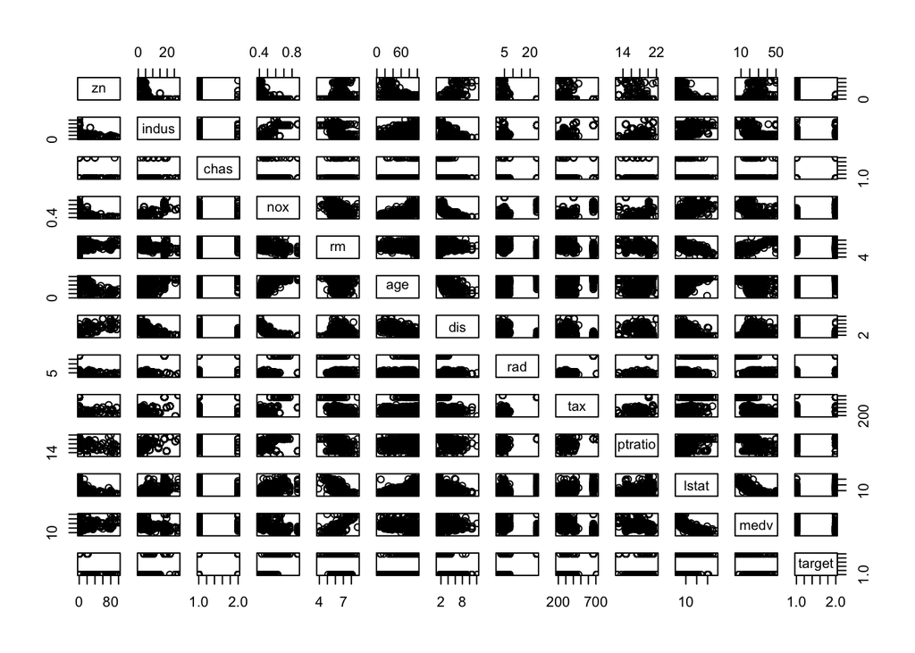

```r
# EDA
pairs(dftrain)
```

[figure not shown]

```r
# Boxplots
par(mfrow = c(4, 3))
boxplot(zn ~ target, data = dftrain)
boxplot(indus ~ target, data = dftrain)
# boxplot(chas ~ target, data=dftrain)
boxplot(nox ~ target, data = dftrain)
boxplot(rm ~ target, data = dftrain)
boxplot(age ~ target, data = dftrain)
boxplot(dis ~ target, data = dftrain)
boxplot(rad ~ target, data = dftrain)
boxplot(tax ~ target, data = dftrain)
boxplot(ptratio ~ target, data = dftrain)
boxplot(lstat ~ target, data = dftrain)
boxplot(medv ~ target, data = dftrain)
```

```r
# Contingency table and jittered plot for chas variable
dfconting <- data.frame(target = dftrain$target, chas = dftrain$chas)
table(dfconting)
```

```
##               chas
## target         not_on_charles on_charles
##   below_median            225         12
##   above_median            208         21
```

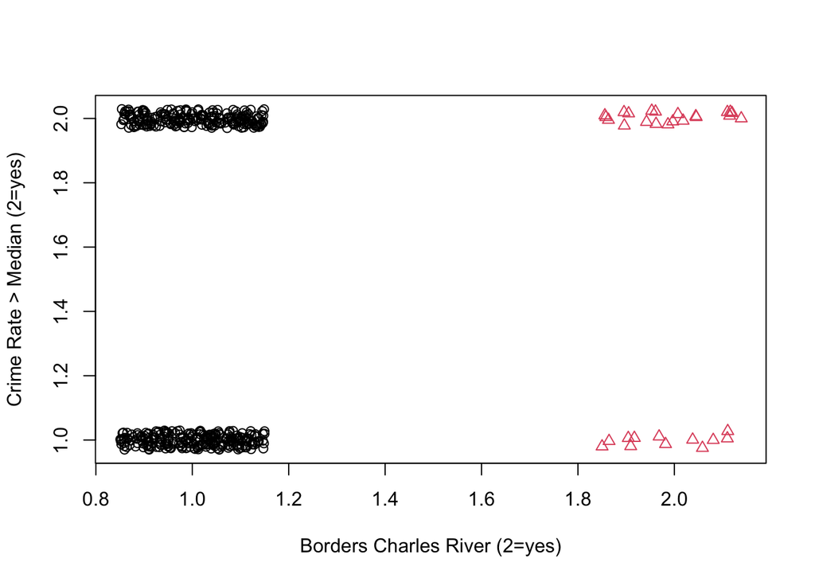

```r
plot(jitter(as.numeric(dftrain$chas), amount = 0.15), jitter(as.numeric(dftrain$target),
    amount = 0.03), xlab = "Borders Charles River (2=yes)", ylab = "Crime Rate > Median (2=yes)",
    col = dftrain$chas, pch = as.numeric(dftrain$chas))
```

### Explore colinearity of predictor variables

```r
# Correlation matrix
print("Correlation matrix (numerical variables):")
```

```
## [1] "Correlation matrix (numerical variables):"
```

```r
round(cor(dftrain[, c(1, 2, 4:12)]), 2)
```

```
##            zn indus   nox    rm   age   dis   rad   tax ptratio lstat  medv
## zn       1.00 -0.54 -0.52  0.32 -0.57  0.66 -0.32 -0.32   -0.39 -0.43  0.38
## indus   -0.54  1.00  0.76 -0.39  0.64 -0.70  0.60  0.73    0.39  0.61 -0.50
## nox     -0.52  0.76  1.00 -0.30  0.74 -0.77  0.60  0.65    0.18  0.60 -0.43
## rm       0.32 -0.39 -0.30  1.00 -0.23  0.20 -0.21 -0.30   -0.36 -0.63  0.71
## age     -0.57  0.64  0.74 -0.23  1.00 -0.75  0.46  0.51    0.26  0.61 -0.38
## dis      0.66 -0.70 -0.77  0.20 -0.75  1.00 -0.49 -0.53   -0.23 -0.51  0.26
## rad     -0.32  0.60  0.60 -0.21  0.46 -0.49  1.00  0.91    0.47  0.50 -0.40
## tax     -0.32  0.73  0.65 -0.30  0.51 -0.53  0.91  1.00    0.47  0.56 -0.49
## ptratio -0.39  0.39  0.18 -0.36  0.26 -0.23  0.47  0.47    1.00  0.38 -0.52
## lstat   -0.43  0.61  0.60 -0.63  0.61 -0.51  0.50  0.56    0.38  1.00 -0.74
## medv     0.38 -0.50 -0.43  0.71 -0.38  0.26 -0.40 -0.49   -0.52 -0.74  1.00
```

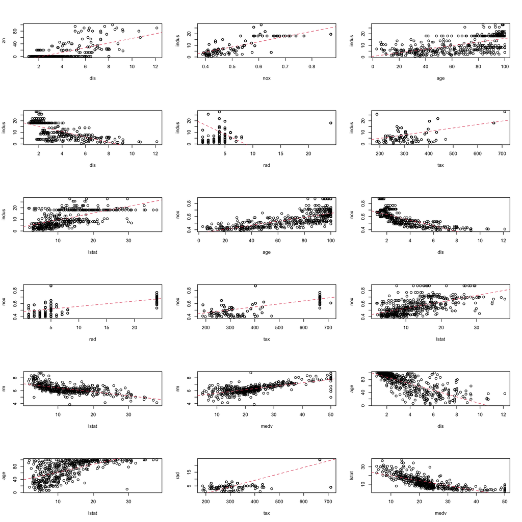

```r
par(mfrow = c(6, 3))

plot(zn ~ dis, data = dftrain)
abline(lm(zn ~ dis, data = dftrain), lt = 2, col = 2)

plot(indus ~ nox, data = dftrain)
abline(lm(indus ~ nox, dftrain), lt = 2, col = 2)

plot(indus ~ age, data = dftrain)
abline(lm(indus ~ age, dftrain), lt = 2, col = 2)

plot(indus ~ dis, data = dftrain)
abline(lm(indus ~ dis, dftrain), lt = 2, col = 2)

plot(indus ~ rad, data = dftrain)
abline(lm(indus ~ dis, dftrain), lt = 2, col = 2)

plot(indus ~ tax, data = dftrain)
abline(lm(indus ~ tax, dftrain), lt = 2, col = 2)

plot(indus ~ lstat, data = dftrain)
abline(lm(indus ~ lstat, dftrain), lt = 2, col = 2)

plot(nox ~ age, data = dftrain)
abline(lm(nox ~ age, dftrain), lt = 2, col = 2)

plot(nox ~ dis, data = dftrain)
abline(lm(nox ~ dis, dftrain), lt = 2, col = 2)

plot(nox ~ rad, data = dftrain)
abline(lm(nox ~ rad, dftrain), lt = 2, col = 2)

plot(nox ~ tax, data = dftrain)
abline(lm(nox ~ tax, dftrain), lt = 2, col = 2)

plot(nox ~ lstat, data = dftrain)
abline(lm(nox ~ lstat, dftrain), lt = 2, col = 2)

plot(rm ~ lstat, data = dftrain)
abline(lm(rm ~ lstat, dftrain), lt = 2, col = 2)

plot(rm ~ medv, data = dftrain)
abline(lm(rm ~ medv, dftrain), lt = 2, col = 2)

plot(age ~ dis, data = dftrain)
abline(lm(age ~ dis, dftrain), lt = 2, col = 2)

plot(age ~ lstat, data = dftrain)
abline(lm(age ~ lstat, dftrain), lt = 2, col = 2)

plot(rad ~ tax, data = dftrain)
abline(lm(rad ~ tax, dftrain), lt = 2, col = 2)

plot(lstat ~ medv, data = dftrain)
abline(lm(lstat ~ medv, dftrain), lt = 2, col = 2)
```

$~$

## Data Preparation:

```r
round(100 * colSums(is.na(dftrain))/nrow(dftrain), 2)
```

```
##      zn   indus    chas     nox      rm     age     dis     rad     tax ptratio
##       0       0       0       0       0       0       0       0       0       0
##   lstat    medv  target
##       0       0       0
```

```r
round(100 * colSums(is.na(dfeval))/nrow(dfeval), 2)
```

```
##      zn   indus    chas     nox      rm     age     dis     rad     tax ptratio
##       0       0       0       0       0       0       0       0       0       0
##   lstat    medv
##       0       0
```

The rad predictor is a categorical value and has some unknown meaning for values 1-8, 24. We need to introduce dummy variables rad1, rad2, etc to indicate if the neighborhood is in which category. We will exclude rad24 since we only need N-1 variables to represent each value.

```r
clean_df <- function(df) {
    df$rad_1 <- ifelse(df$rad == 1, 1, 0)
    df$rad_2 <- ifelse(df$rad == 2, 1, 0)
    df$rad_3 <- ifelse(df$rad == 3, 1, 0)
    df$rad_4 <- ifelse(df$rad == 4, 1, 0)
    df$rad_5 <- ifelse(df$rad == 5, 1, 0)
    df$rad_6 <- ifelse(df$rad == 6, 1, 0)
    df$rad_7 <- ifelse(df$rad == 7, 1, 0)
    df$rad_8 <- ifelse(df$rad == 8, 1, 0)
    df$rad <- NULL
    return(df)
}

dftrain_clean <- clean_df(dftrain)
dftrain_clean <- dftrain_clean %>%
    select(target, everything())
dfeval_clean <- clean_df(dfeval)
```

$~$

## Model Building:

Logistic Regression: Ippolito

```r
# Maximal model for backward elimination
lmod.max <- glm(target ~ ., family = binomial(), data = dftrain)
summary(lmod.max)
```

```
##
## Call:
## glm(formula = target ~ ., family = binomial(), data = dftrain)
##
## Deviance Residuals:
##     Min       1Q   Median       3Q      Max
## -1.8464  -0.1445  -0.0017   0.0029   3.4665
##
## Coefficients:
##                  Estimate Std. Error z value Pr(>|z|)
## (Intercept)    -40.822934   6.632913  -6.155 7.53e-10 ***
## zn              -0.065946   0.034656  -1.903  0.05706 .
## indus           -0.064614   0.047622  -1.357  0.17485
## chason_charles   0.910765   0.755546   1.205  0.22803
## nox             49.122297   7.931706   6.193 5.90e-10 ***
## rm              -0.587488   0.722847  -0.813  0.41637
## age              0.034189   0.013814   2.475  0.01333 *
## dis              0.738660   0.230275   3.208  0.00134 **
## rad              0.666366   0.163152   4.084 4.42e-05 ***
## tax             -0.006171   0.002955  -2.089  0.03674 *
## ptratio          0.402566   0.126627   3.179  0.00148 **
## lstat            0.045869   0.054049   0.849  0.39608
## medv             0.180824   0.068294   2.648  0.00810 **
## ---
## Signif. codes:  0 '***' 0.001 '**' 0.01 '*' 0.05 '.' 0.1 ' ' 1
##
## (Dispersion parameter for binomial family taken to be 1)
##
##     Null deviance: 645.88  on 465  degrees of freedom
## Residual deviance: 192.05  on 453  degrees of freedom
## AIC: 218.05
##
## Number of Fisher Scoring iterations: 9
```

```r
# Backward elimination
lmod.back <- step(lmod.max, data = dftrain, direction = "backward")
```

```
## Start:  AIC=218.05
## target ~ zn + indus + chas + nox + rm + age + dis + rad + tax +
##     ptratio + lstat + medv
##
##           Df Deviance    AIC
## - rm       1   192.71 216.71
## - lstat    1   192.77 216.77
## - chas     1   193.53 217.53
## - indus    1   193.99 217.99
## <none>         192.05 218.05
## - tax      1   196.59 220.59
## - zn       1   196.89 220.89
## - age      1   198.73 222.73
## - medv     1   199.95 223.95
## - ptratio  1   203.32 227.32
## - dis      1   203.84 227.84
## - rad      1   233.74 257.74
## - nox      1   265.05 289.05
##
## Step:  AIC=216.71
## target ~ zn + indus + chas + nox + age + dis + rad + tax + ptratio +
##     lstat + medv
##
##           Df Deviance    AIC
## - chas     1   194.24 216.24
## - lstat    1   194.32 216.32
## - indus    1   194.58 216.58
## <none>         192.71 216.71
## - tax      1   197.59 219.59
## - zn       1   198.07 220.07
## - age      1   199.11 221.11
## - ptratio  1   203.53 225.53
## - dis      1   203.85 225.85
## - medv     1   205.35 227.35
## - rad      1   233.81 255.81
## - nox      1   265.14 287.14
##
## Step:  AIC=216.24
## target ~ zn + indus + nox + age + dis + rad + tax + ptratio +
##     lstat + medv
```

[output cut: 28 more lines]

```
## - nox      1   270.59 288.59
##
## Step:  AIC=215.32
## target ~ zn + nox + age + dis + rad + tax + ptratio + medv
##
##           Df Deviance    AIC
## <none>         197.32 215.32
## - zn       1   203.45 219.45
## - ptratio  1   206.27 222.27
## - age      1   207.13 223.13
## - tax      1   207.62 223.62
## - dis      1   207.64 223.64
## - medv     1   208.65 224.65
## - rad      1   250.98 266.98
## - nox      1   273.18 289.18
```

```r
summary(lmod.back)
```

```
##
## Call:
## glm(formula = target ~ zn + nox + age + dis + rad + tax + ptratio +
##     medv, family = binomial(), data = dftrain)
##
## Deviance Residuals:
##     Min       1Q   Median       3Q      Max
## -1.8295  -0.1752  -0.0021   0.0032   3.4191
##
## Coefficients:
##               Estimate Std. Error z value Pr(>|z|)
## (Intercept) -37.415922   6.035013  -6.200 5.65e-10 ***
## zn           -0.068648   0.032019  -2.144  0.03203 *
## nox          42.807768   6.678692   6.410 1.46e-10 ***
## age           0.032950   0.010951   3.009  0.00262 **
## dis           0.654896   0.214050   3.060  0.00222 **
## rad           0.725109   0.149788   4.841 1.29e-06 ***
## tax          -0.007756   0.002653  -2.924  0.00346 **
## ptratio       0.323628   0.111390   2.905  0.00367 **
## medv          0.110472   0.035445   3.117  0.00183 **
## ---
## Signif. codes:  0 '***' 0.001 '**' 0.01 '*' 0.05 '.' 0.1 ' ' 1
##
## (Dispersion parameter for binomial family taken to be 1)
##
##     Null deviance: 645.88  on 465  degrees of freedom
## Residual deviance: 197.32  on 457  degrees of freedom
## AIC: 215.32
##
## Number of Fisher Scoring iterations: 9
```

```r
# Minimal model for forward elimination
lmod.min <- glm(target ~ 1, family = binomial(), data = dftrain)
summary(lmod.min)
```

```
##
## Call:
## glm(formula = target ~ 1, family = binomial(), data = dftrain)
##
## Deviance Residuals:
##    Min      1Q  Median      3Q     Max
## -1.163  -1.163  -1.163   1.192   1.192
##
## Coefficients:
##             Estimate Std. Error z value Pr(>|z|)
## (Intercept) -0.03434    0.09266  -0.371    0.711
##
## (Dispersion parameter for binomial family taken to be 1)
##
##     Null deviance: 645.88  on 465  degrees of freedom
## Residual deviance: 645.88  on 465  degrees of freedom
## AIC: 647.88
##
## Number of Fisher Scoring iterations: 3
```

```r
lmod.max.form <- formula(lmod.max)

# Forward elimination
lmod.fwd <- step(lmod.min, data = dftrain, direction = "forward",
    scope = lmod.max.form)
```

```
## Start:  AIC=647.88
## target ~ 1
##
##           Df Deviance    AIC
## + nox      1   292.01 296.01
## + rad      1   404.16 408.16
## + dis      1   409.50 413.50
## + age      1   424.75 428.75
## + tax      1   442.38 446.38
## + indus    1   453.23 457.23
## + zn       1   518.46 522.46
## + lstat    1   528.01 532.01
## + medv     1   609.62 613.62
## + ptratio  1   615.64 619.64
## + rm       1   634.82 638.82
## + chas     1   642.86 646.86
## <none>         645.88 647.88
##
## Step:  AIC=296.01
## target ~ nox
##
##           Df Deviance    AIC
## + rad      1   239.51 245.51
## + rm       1   284.63 290.63
## + medv     1   285.86 291.86
## + indus    1   288.11 294.11
## + zn       1   288.29 294.29
## + tax      1   288.40 294.40
## + chas     1   288.47 294.47
## <none>         292.01 296.01
## + ptratio  1   290.13 296.13
## + age      1   290.62 296.62
## + dis      1   290.91 296.91
## + lstat    1   291.93 297.93
##
## Step:  AIC=245.51
## target ~ nox + rad
##
##           Df Deviance    AIC
## + tax      1   224.47 232.47
```

[output cut: 70 more lines]

```
## + chas   1   201.29 219.29
## + rm     1   201.35 219.35
## <none>       203.45 219.45
## + lstat  1   202.05 220.05
## + indus  1   202.23 220.23
##
## Step:  AIC=215.32
## target ~ nox + rad + tax + ptratio + age + medv + dis + zn
##
##         Df Deviance    AIC
## <none>       197.32 215.32
## + lstat  1   195.51 215.51
## + rm     1   195.75 215.75
## + chas   1   195.97 215.97
## + indus  1   196.33 216.33
```

```r
summary(lmod.fwd)
```

```
##
## Call:
## glm(formula = target ~ nox + rad + tax + ptratio + age + medv +
##     dis + zn, family = binomial(), data = dftrain)
##
## Deviance Residuals:
##     Min       1Q   Median       3Q      Max
## -1.8295  -0.1752  -0.0021   0.0032   3.4191
##
## Coefficients:
##               Estimate Std. Error z value Pr(>|z|)
## (Intercept) -37.415922   6.035013  -6.200 5.65e-10 ***
## nox          42.807768   6.678692   6.410 1.46e-10 ***
## rad           0.725109   0.149788   4.841 1.29e-06 ***
## tax          -0.007756   0.002653  -2.924  0.00346 **
## ptratio       0.323628   0.111390   2.905  0.00367 **
## age           0.032950   0.010951   3.009  0.00262 **
## medv          0.110472   0.035445   3.117  0.00183 **
## dis           0.654896   0.214050   3.060  0.00222 **
## zn           -0.068648   0.032019  -2.144  0.03203 *
## ---
## Signif. codes:  0 '***' 0.001 '**' 0.01 '*' 0.05 '.' 0.1 ' ' 1
##
## (Dispersion parameter for binomial family taken to be 1)
##
##     Null deviance: 645.88  on 465  degrees of freedom
## Residual deviance: 197.32  on 457  degrees of freedom
## AIC: 215.32
##
## Number of Fisher Scoring iterations: 9
```

### Linear Model

Logistic Regression: Butler

#### You can’t calculate residuals for a factor so I created a dummy target variable for this model

```r
dftrain_clean_dummy <- dftrain_clean %>%
    mutate(target = as.numeric(target == "above_median"))
olsreg <- lm(data = dftrain_clean_dummy, formula = target ~ .)
summary(olsreg)
```

```
##
## Call:
## lm(formula = target ~ ., data = dftrain_clean_dummy)
##
## Residuals:
##      Min       1Q   Median       3Q      Max
## -0.70893 -0.17857 -0.03795  0.17333  1.02572
##
## Coefficients:
##                  Estimate Std. Error t value Pr(>|t|)
## (Intercept)    -0.5216403  0.3719659  -1.402 0.161495
## zn             -0.0009312  0.0008753  -1.064 0.287955
## indus          -0.0022092  0.0039915  -0.553 0.580214
## chason_charles -0.0733915  0.0530829  -1.383 0.167485
## nox             2.1406483  0.2411727   8.876  < 2e-16 ***
## rm              0.0059837  0.0284320   0.210 0.833408
## age             0.0030372  0.0008144   3.729 0.000217 ***
## dis             0.0024358  0.0129550   0.188 0.850948
## tax            -0.0001335  0.0002407  -0.554 0.579618
## ptratio        -0.0135287  0.0092241  -1.467 0.143171
## lstat           0.0028229  0.0035179   0.802 0.422730
## medv            0.0078729  0.0027222   2.892 0.004014 **
## rad_1          -0.5470800  0.1083242  -5.050 6.44e-07 ***
## rad_2          -0.6743564  0.1112379  -6.062 2.86e-09 ***
## rad_3          -0.5584557  0.1014553  -5.504 6.26e-08 ***
## rad_4          -0.2139619  0.0812526  -2.633 0.008750 **
## rad_5          -0.4966807  0.0825141  -6.019 3.66e-09 ***
## rad_6          -0.6024081  0.0887388  -6.789 3.62e-11 ***
## rad_7          -0.3756072  0.1082244  -3.471 0.000570 ***
## rad_8           0.0565900  0.1017049   0.556 0.578207
## ---
## Signif. codes:  0 '***' 0.001 '**' 0.01 '*' 0.05 '.' 0.1 ' ' 1
##
## Residual standard error: 0.2777 on 446 degrees of freedom
## Multiple R-squared:  0.7046, Adjusted R-squared:  0.692
## F-statistic: 55.99 on 19 and 446 DF,  p-value: < 2.2e-16
```

### Logit Model

```r
logit <- glm(data = dftrain_clean, formula = target ~ ., family = binomial(link = "logit"))
summary(logit)
```

```
##
## Call:
## glm(formula = target ~ ., family = binomial(link = "logit"),
##     data = dftrain_clean)
##
## Deviance Residuals:
##     Min       1Q   Median       3Q      Max
## -2.5265  -0.0409   0.0000   0.0001   4.3848
##
## Coefficients:
##                  Estimate Std. Error z value Pr(>|z|)
## (Intercept)    -1.123e+01  1.944e+03  -0.006   0.9954
## zn             -1.609e-01  6.574e-02  -2.447   0.0144 *
## indus          -1.562e-01  1.166e-01  -1.340   0.1802
## chason_charles -2.603e-01  9.626e-01  -0.270   0.7869
## nox             6.863e+01  1.362e+01   5.038 4.71e-07 ***
## rm             -1.225e+00  1.010e+00  -1.213   0.2250
## age             1.871e-02  1.569e-02   1.193   0.2330
## dis             5.351e-01  2.671e-01   2.003   0.0452 *
## tax            -9.491e-03  5.442e-03  -1.744   0.0811 .
## ptratio         4.824e-02  2.040e-01   0.236   0.8131
## lstat           6.778e-02  6.441e-02   1.052   0.2927
## medv            2.195e-01  9.964e-02   2.203   0.0276 *
## rad_1          -4.404e+01  5.457e+03  -0.008   0.9936
## rad_2          -4.449e+01  5.328e+03  -0.008   0.9933
## rad_3          -2.620e+01  1.944e+03  -0.013   0.9892
## rad_4          -2.182e+01  1.944e+03  -0.011   0.9910
## rad_5          -2.454e+01  1.944e+03  -0.013   0.9899
## rad_6          -2.666e+01  1.944e+03  -0.014   0.9891
## rad_7          -1.704e+01  1.944e+03  -0.009   0.9930
## rad_8          -1.840e+01  1.944e+03  -0.009   0.9924
## ---
## Signif. codes:  0 '***' 0.001 '**' 0.01 '*' 0.05 '.' 0.1 ' ' 1
##
## (Dispersion parameter for binomial family taken to be 1)
##
##     Null deviance: 645.88  on 465  degrees of freedom
## Residual deviance: 116.98  on 446  degrees of freedom
## AIC: 156.98
##
## Number of Fisher Scoring iterations: 20
```

### Logit Model with Backward Elimination

```r
# Backward elimination
lmod.back <- step(logit, data = dftrain_clean, direction = "backward")
```

```
## Start:  AIC=156.98
## target ~ zn + indus + chas + nox + rm + age + dis + tax + ptratio +
##     lstat + medv + rad_1 + rad_2 + rad_3 + rad_4 + rad_5 + rad_6 +
##     rad_7 + rad_8
##
##           Df Deviance    AIC
## - ptratio  1   117.04 155.04
## - chas     1   117.06 155.06
## - lstat    1   118.07 156.07
## - age      1   118.44 156.44
## - rad_7    1   118.47 156.47
## - rm       1   118.50 156.50
## - indus    1   118.82 156.82
## <none>         116.98 156.98
## - rad_8    1   119.91 157.91
## - tax      1   120.42 158.42
## - dis      1   121.06 159.06
## - medv     1   122.98 160.98
## - zn       1   125.74 163.74
## - rad_4    1   137.55 175.55
## - rad_2    1   141.93 179.93
## - rad_3    1   149.43 187.43
## - rad_1    1   156.00 194.00
## - rad_5    1   156.41 194.41
## - rad_6    1   177.89 215.89
## - nox      1   185.39 223.39
##
## Step:  AIC=155.04
## target ~ zn + indus + chas + nox + rm + age + dis + tax + lstat +
##     medv + rad_1 + rad_2 + rad_3 + rad_4 + rad_5 + rad_6 + rad_7 +
##     rad_8
##
##         Df Deviance    AIC
## - chas   1   117.11 153.11
## - lstat  1   118.14 154.15
## - age    1   118.46 154.46
## - rad_7  1   118.47 154.47
## - rm     1   118.53 154.53
## <none>       117.04 155.04
## - indus  1   119.35 155.35
```

[output cut: 107 more lines]

```
##         Df Deviance    AIC
## <none>       123.70 151.70
## - age    1   126.82 152.82
## - rm     1   128.16 154.16
## - dis    1   128.76 154.76
## - medv   1   135.26 161.26
## - zn     1   141.21 167.21
## - rad_4  1   144.35 170.35
## - indus  1   145.93 171.93
## - rad_2  1   162.33 188.33
## - rad_3  1   166.25 192.25
## - rad_1  1   168.22 194.22
## - rad_6  1   194.71 220.71
## - rad_5  1   202.57 228.57
## - nox    1   213.94 239.94
```

```r
summary(lmod.back)
```

```
##
## Call:
## glm(formula = target ~ zn + indus + nox + rm + age + dis + medv +
##     rad_1 + rad_2 + rad_3 + rad_4 + rad_5 + rad_6, family = binomial(link = "logit"),
##     data = dftrain_clean)
##
## Deviance Residuals:
##     Min       1Q   Median       3Q      Max
## -2.2642  -0.0406   0.0000   0.0417   4.6501
##
## Coefficients:
##               Estimate Std. Error z value Pr(>|z|)
## (Intercept)  -27.04848    6.14058  -4.405 1.06e-05 ***
## zn            -0.18143    0.05583  -3.249  0.00116 **
## indus         -0.28923    0.07065  -4.094 4.25e-05 ***
## nox           69.44207   12.13357   5.723 1.05e-08 ***
## rm            -1.69944    0.82175  -2.068  0.03863 *
## age            0.02380    0.01364   1.745  0.08092 .
## dis            0.57815    0.26534   2.179  0.02934 *
## medv           0.24437    0.07962   3.069  0.00215 **
## rad_1        -24.31086 1917.60218  -0.013  0.98988
## rad_2        -22.64510 2049.05400  -0.011  0.99118
## rad_3         -9.10961    2.15021  -4.237 2.27e-05 ***
## rad_4         -4.43125    1.42259  -3.115  0.00184 **
## rad_5         -7.36393    1.50464  -4.894 9.87e-07 ***
## rad_6        -10.00046    2.03065  -4.925 8.45e-07 ***
## ---
## Signif. codes:  0 '***' 0.001 '**' 0.01 '*' 0.05 '.' 0.1 ' ' 1
##
## (Dispersion parameter for binomial family taken to be 1)
##
##     Null deviance: 645.88  on 465  degrees of freedom
## Residual deviance: 123.70  on 452  degrees of freedom
## AIC: 151.7
##
## Number of Fisher Scoring iterations: 18
```

### Logit Minimal Model with forward elimination

```r
# Minimal model for forward elimination
lmod.min <- glm(target ~ 1, family = binomial(), data = dftrain_clean)
summary(lmod.min)
```

```
##
## Call:
## glm(formula = target ~ 1, family = binomial(), data = dftrain_clean)
##
## Deviance Residuals:
##    Min      1Q  Median      3Q     Max
## -1.163  -1.163  -1.163   1.192   1.192
##
## Coefficients:
##             Estimate Std. Error z value Pr(>|z|)
## (Intercept) -0.03434    0.09266  -0.371    0.711
##
## (Dispersion parameter for binomial family taken to be 1)
##
##     Null deviance: 645.88  on 465  degrees of freedom
## Residual deviance: 645.88  on 465  degrees of freedom
## AIC: 647.88
##
## Number of Fisher Scoring iterations: 3
```

```r
# Forward elimination
lmod.fwd <- step(lmod.min, data = dftrain_clean, direction = "forward",
    scope = formula(logit))
```

```
## Start:  AIC=647.88
## target ~ 1
##
##           Df Deviance    AIC
## + nox      1   292.01 296.01
## + dis      1   409.50 413.50
## + age      1   424.75 428.75
## + tax      1   442.38 446.38
## + indus    1   453.23 457.23
## + zn       1   518.46 522.46
## + lstat    1   528.01 532.01
## + rad_3    1   603.67 607.67
## + medv     1   609.62 613.62
## + ptratio  1   615.64 619.64
## + rad_2    1   617.96 621.96
## + rad_1    1   622.27 626.27
## + rad_6    1   624.91 628.91
## + rm       1   634.82 638.82
## + rad_7    1   636.98 640.98
## + rad_8    1   637.41 641.41
## + rad_5    1   640.49 644.49
## + chas     1   642.86 646.86
## + rad_4    1   643.69 647.69
## <none>         645.88 647.88
##
## Step:  AIC=296.01
## target ~ nox
##
##           Df Deviance    AIC
## + rad_8    1   254.85 260.85
## + rad_6    1   268.66 274.66
## + rad_2    1   274.39 280.39
## + rad_1    1   278.70 284.70
## + rad_5    1   279.56 285.56
## + rad_4    1   284.30 290.30
## + rm       1   284.63 290.63
## + medv     1   285.86 291.86
## + indus    1   288.11 294.11
## + zn       1   288.29 294.29
## + tax      1   288.40 294.40
```

[output cut: 221 more lines]

```
## + age      1   123.53 153.53
## + chas     1   123.56 153.56
## + ptratio  1   123.56 153.56
##
## Step:  AIC=150.57
## target ~ nox + rad_8 + rad_6 + rad_2 + rad_5 + rad_1 + indus +
##     rad_3 + rad_4 + zn + tax + medv + lstat + dis
##
##           Df Deviance    AIC
## <none>         120.57 150.57
## + rad_7    1   119.15 151.15
## + rm       1   119.78 151.78
## + age      1   120.03 152.03
## + ptratio  1   120.36 152.36
## + chas     1   120.55 152.55
```

```r
summary(lmod.fwd)
```

```
##
## Call:
## glm(formula = target ~ nox + rad_8 + rad_6 + rad_2 + rad_5 +
##     rad_1 + indus + rad_3 + rad_4 + zn + tax + medv + lstat +
##     dis, family = binomial(), data = dftrain_clean)
##
## Deviance Residuals:
##     Min       1Q   Median       3Q      Max
## -2.7310  -0.0446   0.0000   0.0249   4.4357
##
## Coefficients:
##               Estimate Std. Error z value Pr(>|z|)
## (Intercept) -3.269e+01  6.572e+00  -4.973 6.58e-07 ***
## nox          7.284e+01  1.205e+01   6.047 1.47e-09 ***
## rad_8       -2.257e+00  2.054e+00  -1.099 0.271886
## rad_6       -1.144e+01  2.151e+00  -5.318 1.05e-07 ***
## rad_2       -2.634e+01  1.870e+03  -0.014 0.988765
## rad_5       -8.768e+00  1.685e+00  -5.203 1.96e-07 ***
## rad_1       -2.665e+01  1.874e+03  -0.014 0.988657
## indus       -1.909e-01  9.350e-02  -2.042 0.041133 *
## rad_3       -9.875e+00  2.141e+00  -4.613 3.96e-06 ***
## rad_4       -6.221e+00  1.661e+00  -3.746 0.000180 ***
## zn          -2.021e-01  5.393e-02  -3.748 0.000178 ***
## tax         -8.233e-03  4.286e-03  -1.921 0.054745 .
## medv         1.300e-01  4.997e-02   2.601 0.009293 **
## lstat        1.176e-01  5.911e-02   1.989 0.046732 *
## dis          4.204e-01  2.439e-01   1.724 0.084742 .
## ---
## Signif. codes:  0 '***' 0.001 '**' 0.01 '*' 0.05 '.' 0.1 ' ' 1
##
## (Dispersion parameter for binomial family taken to be 1)
##
##     Null deviance: 645.88  on 465  degrees of freedom
## Residual deviance: 120.57  on 451  degrees of freedom
## AIC: 150.57
##
## Number of Fisher Scoring iterations: 18
```

$~$

## Select Models:

#### Here we are evaluating the performance our models to decide which model should we use

#### **Linear Model Accuracy**

```r
table(true = dftrain_clean_dummy$target, pred = round(fitted(olsreg)))
```

```
##     pred
## true   0   1
##    0 225  12
##    1  19 210
```

Accuracy: $\frac{210+225}{466}=93\%$

Classification Error Rate: $\frac{12+19}{466}=7\%$

Precision: $\frac{210}{210+12}=95\%$

Sensitivity: $\frac{210}{210+19}=92\%$

Specificity: $\frac{225}{225+12}=95\%$

F1 Score: $\frac{2 * .95 * .92}{.95 + .92}=93\%$

#### **Logit Model Prediction Accuracy**

```r
table(true = dftrain_clean$target, pred = round(fitted(logit)))
```

```
##               pred
## true             0   1
##   below_median 233   4
##   above_median  10 219
```

Accuracy: $\frac{219+233}{466}=97\%$

Classification Error Rate: $\frac{4+10}{466}=3\%$

Precision: $\frac{219}{219+4}=98\%$

Sensitivity: $\frac{219}{219+10}=96\%$

Specificity: $\frac{233}{233+4}=98\%$

F1 Score: $\frac{2 * .98 * .96}{.98 + .96}=97\%$

#### **Logit Model with Forward Elimination Prediction Accuracy**

```r
table(true = dftrain_clean$target, pred = round(fitted(lmod.fwd)))
```

```
##               pred
## true             0   1
##   below_median 234   3
##   above_median   9 220
```

Accuracy: $\frac{220+234}{466}=97\%$

Precision: $\frac{220}{220+3}=99\%$

Sensitivity: $\frac{220}{220+9}=96\%$

Specificity: $\frac{234}{234+3}=98\%$

F1 Score: $\frac{2 * .99 * .96}{.99 + .96}=97\%$

#### **Logit Model with Backward Elimination Prediction Accuracy**

```r
table(true = dftrain_clean$target, pred = round(fitted(lmod.back)))
```

```
##               pred
## true             0   1
##   below_median 232   5
##   above_median  12 217
```

Accuracy: $\frac{217+232}{466}=96\%$

Classification Error Rate: $\frac{5+12}{466}=4\%$

Precision: $\frac{217}{217+5}=98\%$

Sensitivity: $\frac{217}{217+12}=95\%$

Specificity: $\frac{232}{232+5}=98\%$

F1 Score: $\frac{2 * .98 * .95}{.98 + .95}=96\%$

### Model AUCs

- Linear Model

```r
pred = round(fitted(olsreg))
pROC::auc(dftrain_clean_dummy$target, pred)
```

```
## Area under the curve: 0.9332
```

- Logit Model

```r
pred = round(fitted(logit))
pROC::auc(dftrain_clean$target, pred)
```

```
## Area under the curve: 0.9697
```

- Logit Model with Forward Elimination

```r
pred = round(fitted(lmod.fwd))
pROC::auc(dftrain_clean$target, pred)
```

```
## Area under the curve: 0.974
```

- Logit Model with Backward Elimination

```r
pred = round(fitted(lmod.back))
pROC::auc(dftrain_clean$target, pred)
```

```
## Area under the curve: 0.9633
```

#### Findings

All of our Logistic Models had a better AUC than our Linear Model with Logit with Forward Elimination having the best (0.974)

Now lets make predictions with the evaluation df

- Linear Model

```r
prediction <- broom::augment(olsreg, newdata = dfeval_clean)
prediction$.fitted
```

```
##  [1]  0.044471432  0.549248991  0.590432182  0.549527352  0.100429012
##  [6]  0.602991759  0.668344513  0.036611979  0.004762499 -0.072870822
## [11]  0.249882596  0.236346164  0.697204745  0.529904005  0.501715088
## [16]  0.470213603  0.694800279  0.993663602  0.016477435 -0.148806180
## [21] -0.251508242  0.272093476  0.511840154  0.103025106  0.054423115
## [26]  0.174900012  0.209310715  1.142008184  1.096606893  0.794790626
## [31]  1.129376086  1.148942218  1.125367437  1.197800888  1.145515096
## [36]  1.072375460  1.096093208  0.927138131  0.234910336  0.338470879
```

- Logit Model

```r
prediction <- broom::augment(logit, newdata = dfeval_clean)
prediction$.fitted
```

```
##  [1] -23.1837846   1.8909140   1.7995517   1.8557650  -3.2553526  -2.0334222
##  [7]  -2.5229875  -7.1842002  -7.7530724 -26.2911541 -19.5120234 -19.5664789
## [13]   3.5376684   1.2190996   0.4821279  -0.7066933   3.2735770   6.1682811
## [19]  -2.2482983 -41.5077624 -40.2884118  -1.1204161   0.8969585  -3.5445734
## [25]  -3.6931577  -0.7112376 -15.5439099  34.5405444  28.6931706  19.9909294
## [31]  30.8838151  31.5823360  30.7894623  31.8744218  31.0194002  28.7850963
## [37]  29.6277567  26.3487159  -1.2933127 -19.4359816
```

- Logit Model with Forward Elimination

```r
prediction <- broom::augment(lmod.fwd, newdata = dfeval_clean)
prediction$.fitted
```

```
##  [1] -21.1324127   1.6471631   1.9687105   2.8502070  -3.1267587  -3.3028850
##  [7]  -3.6732098  -6.6556256  -7.2930650 -23.8504338 -17.0961819 -17.1653572
## [13]   3.6153389   0.9210658   0.4594639  -1.1097315   4.0131436   6.5538691
## [19]  -1.5678079 -43.1228507 -41.8272191  -1.0616325   1.0108975  -3.3616476
## [25]  -3.3259980  -0.7694337 -18.6851352  15.7643086  11.6898199   5.7354155
## [31]  18.1336636  17.3945880  17.0257378  17.4618888  17.2745735  15.2985175
## [37]  15.4125285  11.6671505  -1.3291711 -17.4399249
```

- Logit Model with Backward Elimination

```r
prediction <- broom::augment(lmod.back, newdata = dfeval_clean)
prediction$.fitted
```

```
##  [1] -18.5749014   2.2043350   1.8065924   0.8982560  -3.0322514  -1.0444374
##  [7]  -1.6745047  -7.1433557  -7.7359050 -21.1945465 -19.0579804 -19.1775642
## [13]   2.8342223   1.2115299   0.3085187  -0.9777271   5.1807736   7.9402710
## [19]  -2.0835523 -40.2270283 -39.3183668  -1.8615699   1.2132010  -3.4206755
## [25]  -3.5992473  -0.9833513 -16.1256587  21.2691328  14.8455059   4.2619536
## [31]  14.2147561  15.9542636  15.0602397  16.5703311  15.1893301  13.0524380
## [37]  14.3065313  11.1485972  -1.2497896 -17.6153601
```

$~$

## References: